# regression_grp10_project

To do's :-

1. Model Fittng (full)
2. **Box-Tidwell** is required or not
3. Normality assumption for y-variable otherwise use Box-Cox Transformation
4. Check for variable importances and then find adequate variables
5. Fit model with adequate variables and then other assumptions - **constant variance**
6. Check for **influential obervations**
7. - Check for interaction terms as well

#### Importing necessary libraries

```python
import numpy as np
import pandas as pd
import matplotlib.pyplot as plt
import seaborn as sns
```

```python
df=pd.read_excel(r"C:\Users\hp\Downloads\Semester 2 Project\project_dataset.xlsx")
```

```python
df.drop(columns = ["id"], inplace = True)
```

```python
df = df.rename(columns={"x6 " : "x6"})
```

#### Exploratory Data Analysis

```python
df
```

|  | x1 | x2 | x3 | x4 | x5 | x6 | x7 | x8 | x9 | x10 | y |
| --- | --- | --- | --- | --- | --- | --- | --- | --- | --- | --- | --- |
| 0 | 7.13 | 55.7 | 9.0 | 39.6 | 279 | 2 | 4 | 207 | 241 | 60.0 | 4.1 |
| 1 | 8.82 | 58.2 | 3.8 | 51.7 | 80 | 2 | 2 | 51 | 52 | 40.0 | 1.6 |
| 2 | 8.34 | 56.9 | 8.1 | 74.0 | 107 | 2 | 3 | 82 | 54 | 20.0 | 2.7 |
| 3 | 8.95 | 53.7 | 18.9 | 122.8 | 147 | 2 | 4 | 53 | 148 | 40.0 | 5.6 |
| 4 | 11.20 | 56.5 | 34.5 | 88.9 | 180 | 2 | 1 | 134 | 151 | 40.0 | 5.7 |
| ... | ... | ... | ... | ... | ... | ... | ... | ... | ... | ... | ... |
| 108 | 11.80 | 53.8 | 9.1 | 116.9 | 571 | 1 | 2 | 441 | 469 | 62.9 | 5.7 |
| 109 | 9.50 | 49.3 | 42.0 | 70.9 | 98 | 2 | 3 | 68 | 46 | 22.9 | 5.8 |
| 110 | 7.70 | 56.9 | 12.2 | 67.9 | 129 | 2 | 4 | 85 | 136 | 62.9 | 4.4 |
| 111 | 17.94 | 56.2 | 26.4 | 91.8 | 835 | 1 | 1 | 791 | 407 | 62.9 | 5.9 |
| 112 | 9.41 | 59.5 | 20.6 | 91.7 | 29 | 2 | 3 | 20 | 22 | 22.9 | 3.1 |

113 rows × 11 columns

```python
df.info()
```

```
<class 'pandas.core.frame.DataFrame'>
RangeIndex: 113 entries, 0 to 112
Data columns (total 11 columns):
 #   Column  Non-Null Count  Dtype
---  ------  --------------  -----
 0   x1      113 non-null    float64
 1   x2      113 non-null    float64
 2   x3      113 non-null    float64
 3   x4      113 non-null    float64
 4   x5      113 non-null    int64
 5   x6      113 non-null    int64
 6   x7      113 non-null    int64
 7   x8      113 non-null    int64
 8   x9      113 non-null    int64
 9   x10     113 non-null    float64
 10  y       113 non-null    float64
dtypes: float64(6), int64(5)
memory usage: 9.8 KB
```

```python
df["x6"].unique()
```

```
array([2, 1], dtype=int64)
```

```python
df["x7"].unique()
```

```
array([4, 2, 3, 1], dtype=int64)
```

```
So, x6 and x7 are categorical columns.
```

```python
df.shape
```

```
(113, 11)
```

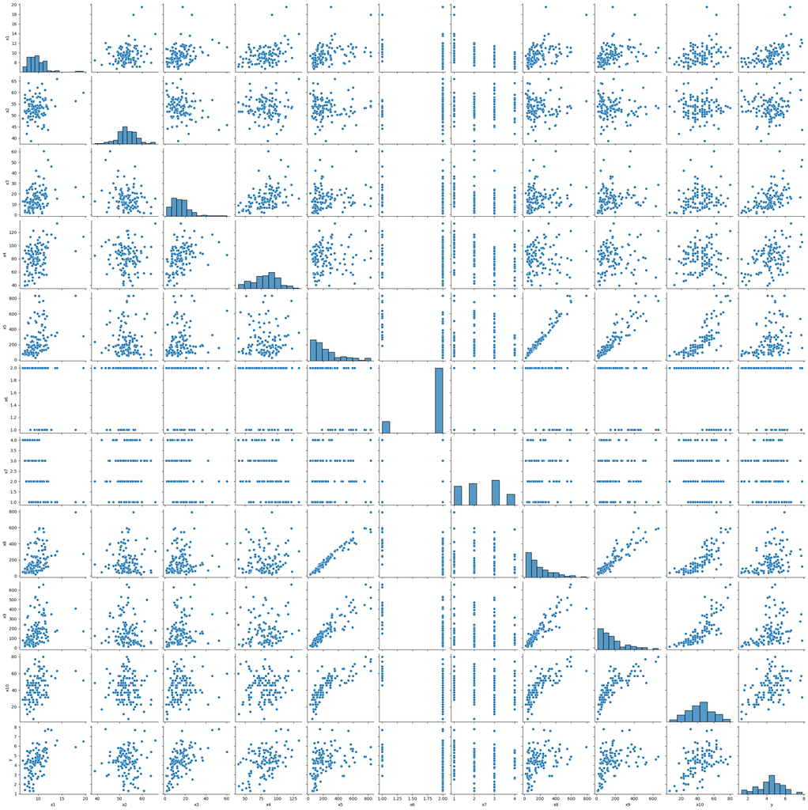

```python
sns.pairplot(df)
```

So, after carefully visualising this pair plot we can make these conclusions

1. We can see that the variables are associated with y variable but, they are not completly linear with each other. Therefore, **Box-Tidwell** Transformation may be needed here.
2. x1, x4 and x10 are looking somewhat linear and may be beneficial in further stage of our model building columns.
3. X5 is linearly related with x8, x9 and x10.

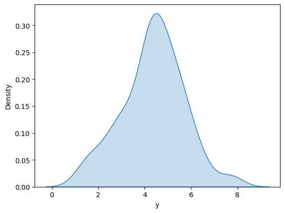

```python
sns.kdeplot(df["y"], fill=True)
```

We can see that the kde plot looks very much similar to normal distribution, but we can not directly comment of the normality assum[tion of y-variable by just seeing seeing this plot. We will have to plot QQ-Plot as well.

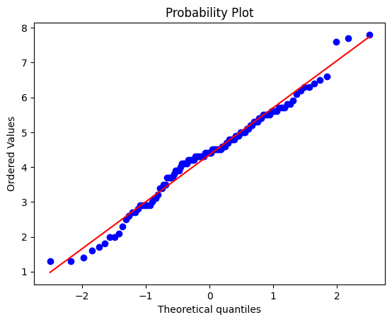

```python
from scipy.stats import probplot

probplot(df["y"], dist="norm", plot = plt)
plt.show()
```

A little deviation can be seen and we will see what we have to do for the **normality** assumption.

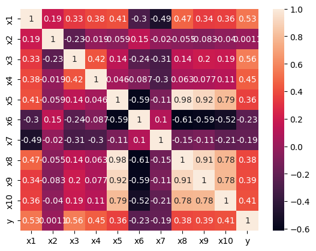

```python
sns.heatmap(data = df.corr(), annot = True)
```

Conclusions :-

1. x5 can be seen highly correlated with x8, x9 and x10.
2. x6 can be been moderately correlated with x5, x8 and x9. (correlation around 0.6)
3. x8 can be seen highly correlated with x9 and x10. (x5 k saath to hai hi)
4. x9 and x10 are highly correlated.

So, multicollinearity could have been an issue here.

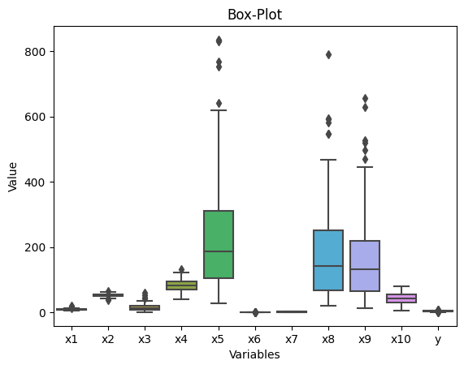

```python
sns.boxplot(df)

plt.xlabel('Variables')
plt.ylabel('Value')
plt.title('Box-Plot')

plt.show()
```

So, we can see that **x5**, **x8** and **x9** have some outliers in them as well.

#### One-Hot encoding for x6 and x7

```python
df = pd.get_dummies(df, columns=["x7", "x6"], drop_first=True)
```

```python
df["x6_2"] = df["x6_2"].astype(int)
df["x7_2"] = df["x7_2"].astype(int)
df["x7_3"] = df["x7_3"].astype(int)
df["x7_4"] = df["x7_4"].astype(int)
```

```python
df.head()
```

|  | x1 | x2 | x3 | x4 | x5 | x8 | x9 | x10 | y | x7_2 | x7_3 | x7_4 | x6_2 |
| --- | --- | --- | --- | --- | --- | --- | --- | --- | --- | --- | --- | --- | --- |
| 0 | 7.13 | 55.7 | 9.0 | 39.6 | 279 | 207 | 241 | 60.0 | 4.1 | 0 | 0 | 1 | 1 |
| 1 | 8.82 | 58.2 | 3.8 | 51.7 | 80 | 51 | 52 | 40.0 | 1.6 | 1 | 0 | 0 | 1 |
| 2 | 8.34 | 56.9 | 8.1 | 74.0 | 107 | 82 | 54 | 20.0 | 2.7 | 0 | 1 | 0 | 1 |
| 3 | 8.95 | 53.7 | 18.9 | 122.8 | 147 | 53 | 148 | 40.0 | 5.6 | 0 | 0 | 1 | 1 |
| 4 | 11.20 | 56.5 | 34.5 | 88.9 | 180 | 134 | 151 | 40.0 | 5.7 | 0 | 0 | 0 | 1 |

#### Box-Tidwell (Linearity Assumption)

As we can see that the varibles are not too linear with the y-variable. So, we will try to find an alpha for the variable using **Box-Tidwell transformation** and see how far we can go.

**Procedure** :-

```
1. Take input x and y
2. Fit a  simple linear regression model
3. Obtain \beta_1(old)
4. Fit LR Model : **y = \beta_0 + \beta_1(new) * x + \beta_2 * (x * logx)**
5. Find alpha = (\beta_2 / \beta_1(old)) + 1
```

```python
from sklearn.linear_model import LinearRegression
```

```python
import statsmodels.api as sm
from statsmodels.formula.api import ols
```

```python
def box_tidwell(x, y):
    x = sm.add_constant(x)
    lr1 = sm.OLS(y, x).fit()

    beta_1 = lr1.params[-1] # find beta_1

    x["xlogx"] = x.iloc[:, -1] * np.log(x.iloc[:, -1])

    lr2 = sm.OLS(y, x).fit() # Fit second model

    beta_2 = lr2.params[-1] # find beta_2

    # alpha
    alpha  = (beta_2/beta_1) + 1

    return alpha
```

```python
# defining columns or box-tidwell

col = df.columns
col = list(col)

cat_col = ["x6_2", "x7_2", "x7_3", "x7_4"]

for i in cat_col:
    col.remove(i)
# since they were categorical columns

col.remove("y")

col
```

```
['x1', 'x2', 'x3', 'x4', 'x5', 'x8', 'x9', 'x10']
```

```python
alphas = {}
for i in col:
    a = box_tidwell(pd.DataFrame(df[i]), pd.DataFrame(df["y"]))
    alphas[i] = a

print(alphas)
```

```
{'x1': -0.5253179340006215, 'x2': 696.2729262185024, 'x3': -0.09282219256014179, 'x4': 1.50455419439544, 'x5': -1.5613257815153019, 'x8': -0.849404288287531, 'x9': -1.7676528018773272, 'x10': -1.5257239771594349}
```

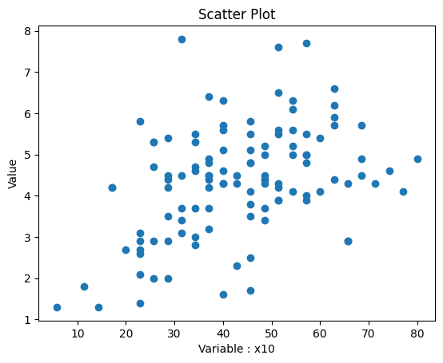

```python
plt.scatter(df["x10"], df["y"])

plt.xlabel('Variable : x10')
plt.ylabel('Value')
plt.title('Scatter Plot')

plt.show()
```

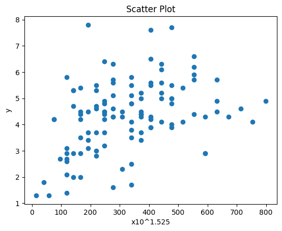

```python
plt.scatter((df["x10"])**(1.525), df["y"])

plt.xlabel('x10^1.525')
plt.ylabel('y')
plt.title('Scatter Plot')

plt.show()
```

x5 - log

Conclusions of Box-Tidwell :-

[output not shown]

### Linear Model Pipeline

```python
data_for_mse = df.copy()
```

```python
x = data_for_mse.drop(columns=["y"], axis=1)
y = data_for_mse["y"]
x = sm.add_constant(x)
model = sm.OLS(y, x).fit()
y_pred = model.predict(x)
SSE = np.sum((y - y_pred)**2)
MSE = SSE / (data_for_mse.shape[0] - data_for_mse.shape[1])

print("MSE for full model is : ", MSE)
```

```
MSE for full model is :  0.8350025562952726
```

```python
class LinearModel:
    def __init__(self, data):
        self.data = data
        self.n = self.data.shape[0]
        self.p = self.data.shape[1]
        self.x = data.drop(columns=["y"], axis=1)
        self.y = data["y"]
        self.x = sm.add_constant(self.x)
        self.model = sm.OLS(self.y, self.x).fit()
        self.y_pred = self.model.predict(self.x)
        self.SSE = np.sum((self.y - self.y_pred)**2)
        self.SSR = np.sum((self.y_pred - np.mean(self.y))**2)
        self.SSTO = self.SSE + self.SSR
        self.dfSSE = self.n - self.p
        self.dfSSR = self.p - 1
        self.dfSSTO = self.n - 1
        self.residual = self.y - self.y_pred

    def r_squared(self):
        # Get the R-Squared
        return (1 - self.SSE/self.SSTO)

    def adjustedr_squared(self):
        # Get Adjusted R-Squared
        return (1 - (self.SSE/self.dfSSE)/(self.SSTO/self.dfSSTO))

    def Cp(self, MSE):
        # Get Cp
        return ((self.SSE/MSE) - self.n + 2 * self.p)

    def AIC(self):
        # Get AIC
        return (self.n * np.log(self.SSE/self.n) + 2 * self.p)

    def BIC(self):
        # Get BIC
        return (self.n * np.log(self.SSE/self.n) + np.log(self.n) * self.p)
```

### Model Fitting (Full Model, without any changes)

```python
model_full = LinearModel(df)
```

```python
# Print the R-Squared
print(f"R-Squared on Test Data for full model: {model_full.r_squared()}")

# Print the Adjusted R-Squared
print(f"Adjusted R-Squared on Test Data for full model: {model_full.adjustedr_squared()}")

# Print the Adjusted R-Squared
print(f"Mallow's Statistic on Data for full model: {model_full.Cp(MSE)}")

# Print the AIC
print(f"AIC on Data for full model: {model_full.AIC()}")

# Print the BIC
print(f"BIC on Data for full model: {model_full.BIC()}")
```

```
R-Squared on Test Data for full model: 0.5853593752247047
Adjusted R-Squared on Test Data for full model: 0.5356025002516693
Mallow's Statistic on Data for full model: 13.0
AIC on Data for full model: -8.186808173449066
BIC on Data for full model: 27.26923346981137
```

Residual Plot

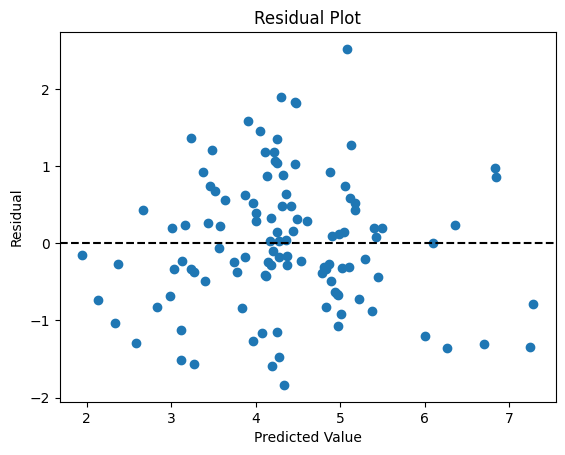

```python
plt.scatter(model_full.y_pred, (model_full.y - model_full.y_pred))
plt.axhline(0, color='black', linestyle='--')  # Draw a horizontal line at y=0
plt.title("Residual Plot")
plt.ylabel("Residual")
plt.xlabel("Predicted Value")
plt.show()
```

```python
# Print the Residual Mean
print(f"Residual Mean on Test Data for full model: {np.mean(model_full.residual)}")
```

```
Residual Mean on Test Data for full model: 1.9433815422199644e-14
```

### Data Frame for Box-Tidwell

```python
df1 = df.copy()
```

##### Model Fitting (Model, with Box - Tidwell changes)

[output not shown]

```python
df1['x1'] = df1['x1']**0.525
df1['x3'] = np.log(df1['x3'])
df1['x9'] = np.log(df1['x9'])
df1['x10'] = df1['x10']**1.52
df1['x4'] = df1['x4']**1.5
df1['x5'] = df1['x5']**(-1.56)
df1['x8'] = df1['x8']**(-0.84)
```

```python
model1 = LinearModel(df1)

# Print the R-Squared
print(f"R-Squared on Test Data for full model: {model1.r_squared()}")
```

```
R-Squared on Test Data for full model: 0.6522866508330935
```

```python
# Print the Adjusted R-Squared
print(f"Adjusted R-Squared on Test Data for full model: {model1.adjustedr_squared()}")
```

```
Adjusted R-Squared on Test Data for full model: 0.6105610489330646
```

#### Residual Plot

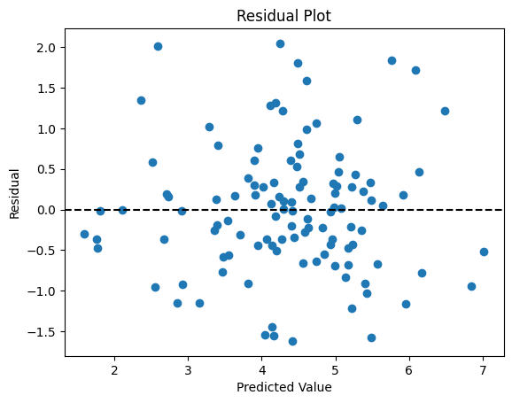

```python
plt.scatter(model1.y_pred, (model1.y - model1.y_pred))
plt.axhline(0, color='black', linestyle='--')  # Draw a horizontal line at y=0
plt.title("Residual Plot")
plt.ylabel("Residual")
plt.xlabel("Predicted Value")
plt.show()
```

```python
# Print the Residual Mean
print(f"Residual Mean on Test Data for full model: {np.mean(model1.residual)}")
```

```
Residual Mean on Test Data for full model: -2.060652533564441e-13
```

#### Normality Assumption

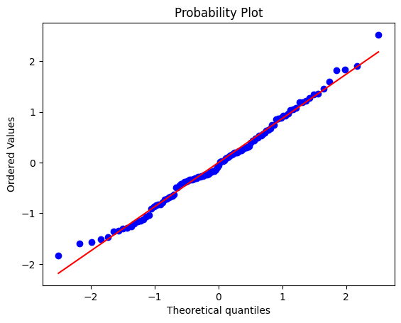

```python
probplot(model_full.residual, dist="norm", plot = plt)
plt.show()
```

#### Box-Cox Transformation

```python
from scipy import stats

# Apply Box-Cox transformation
transformed_data, lambda_value = stats.boxcox(df["y"])

print("Lambda value:", lambda_value)
print("Transformed data:", transformed_data)
```

[output not shown]

```
Since, the lambda value for the y-variable is 1.09 which is close to 1, therefore normality assumption is satisfied.
```

#### Handling Multicollinearity

Creating function for calculating VIF

```python
def VIF(data):
    model_vif = LinearModel(data)
    return(1 / (1 - model_vif.r_squared()))


def vif_values(data):
    data = data.drop(columns = ["y"], axis = 1)
    VIFs = {}
    for i in data.columns:
        data1 = data.rename(columns = {i : "y"})
        VIFs[i] = VIF(data1)

    return VIFs
```

```python
vif_values(df1)
```

```
{'x1': 2.2806748598102384,
 'x2': 1.4184303408173529,
 'x3': 1.750576216383295,
 'x4': 1.5021224378653086,
 'x5': 6.778982809774916,
 'x8': 14.435307674916789,
 'x9': 6.864121483963243,
 'x10': 4.02562644738662,
 'x7_2': 1.8623032802930388,
 'x7_3': 2.20953450920846,
 'x7_4': 1.9914977569351193,
 'x6_2': 1.5931479149924948}
```

```
Now, after variable transformations, x8 has to be treated, else we can see that handling the multicollinearity has automatically sorted out.
```

Conclusions (before variable transformation) for these VIF values :-

```
1. x5, x8 and x9 have high VIF which can also be seen in the pairplot as well.
2. x5 and x8 are highly correlated with each other and they **have** to treated.
```

##### Creating new dataframe after treating multicollinearity as well -

```python
df2 = df1.copy()
```

```python
df2.drop(columns=["x8"], axis=1, inplace=True)
```

```python
vif_values(df2)
```

```
{'x1': 2.0109704484823627,
 'x2': 1.3362749533218545,
 'x3': 1.7394856432280446,
 'x4': 1.4928962763536524,
 'x5': 2.1854457281991686,
 'x9': 5.47255333419414,
 'x10': 3.8348338230907792,
 'x7_2': 1.860629088103774,
 'x7_3': 2.082599246574338,
 'x7_4': 1.896916486100812,
 'x6_2': 1.5876511188460174}
```

```
So, now everything is sorted.
```

```python
model2 = LinearModel(df2)

# Print the R-Squared
print(f"R-Squared on Test Data for full model: {model2.r_squared()}")
```

```
R-Squared on Test Data for full model: 0.6497742904484571
```

```python
# Print the Adjusted R-Squared
print(f"Adjusted R-Squared on Test Data for full model: {model2.adjustedr_squared()}")
```

```
Adjusted R-Squared on Test Data for full model: 0.611630896338883
```

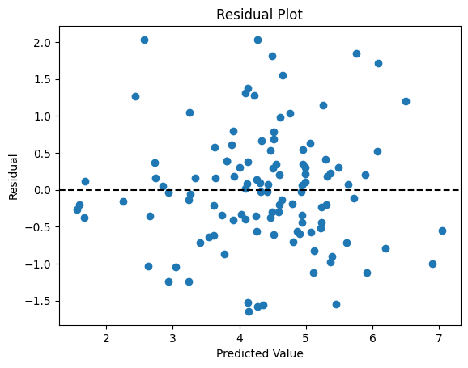

```python
plt.scatter(model2.y_pred, (model2.y - model2.y_pred))
plt.axhline(0, color='black', linestyle='--')  # Draw a horizontal line at y=0
plt.title("Residual Plot")
plt.ylabel("Residual")
plt.xlabel("Predicted Value")
plt.show()
```

```python
# Print the Residual Mean
print(f"Residual Mean on Test Data for model: {np.mean(model2.residual)}")
```

```
Residual Mean on Test Data for model: 2.929750837213044e-13
```

### Best Model Selection

```
1. Using R-Squared
2. Using Adjusted R-Squared
3. Using Mallow's Statistic
4. Using Sequential Selection Techniques (Backward Elimination, Forward Selection)
5. Using AIC-BIC
```

```python
x = df2.drop(columns=['y'], axis =1)
columns = list(x.columns)

columns
```

```
['x1', 'x2', 'x3', 'x4', 'x5', 'x9', 'x10', 'x7_2', 'x7_3', 'x7_4', 'x6_2']
```

```
### Creating Data Frame for all the metrics
```

```python
import itertools

# to create combinations of variables
```

```python
Variables_in_Model = []
p = []
SSE_p = []
R_Squared = []
Adjusted_R_Squared = []
Cp = []
AIC = []
BIC = []
```

```python
for i in range(1, 13):
    for predictors in itertools.combinations(columns, i):
        x_subset = x[list(predictors)]
        x_subset['y'] = df2['y']
        eval_model = LinearModel(x_subset)
        Variables_in_Model.append(list(predictors))
        p.append(i)
        SSE_p.append(eval_model.SSE)
        R_Squared.append(eval_model.r_squared())
        Adjusted_R_Squared.append(eval_model.adjustedr_squared())
        Cp.append(eval_model.Cp(MSE))
        AIC.append(eval_model.AIC())
        BIC.append(eval_model.BIC())
```

[output not shown]

[output cut: 12155 more lines]

[output not shown]

```python
eval_metrics = pd.DataFrame({"Variables in Model" : Variables_in_Model, "p" : p, "SSE" : SSE_p, "R_Squared" : R_Squared, "Adjusted R_Squared" : Adjusted_R_Squared, "Cp" : Cp, "AIC" : AIC, "BIC" : BIC})
```

```python
eval_metrics.shape
```

```
(2047, 8)
```

Since, we had 11 variable and used atleast 1 variable in the model, therefore total 2^11 - 1 = 2048 - 1 = 2047 models are there.

```python
eval_metrics.sample(10)
```

|  | Variables in Model | p | SSE | R_Squared | Adjusted R_Squared | Cp | AIC | BIC |
| --- | --- | --- | --- | --- | --- | --- | --- | --- |
| 1553 | [x1, x2, x3, x10, x7_3, x7_4, x6_2] | 7 | 83.553162 | 0.585097 | 0.557436 | 3.063360 | -18.115234 | 3.703869 |
| 643 | [x1, x2, x7_2, x7_4, x6_2] | 5 | 129.512098 | 0.356876 | 0.326824 | 54.103834 | 27.411672 | 43.775999 |
| 817 | [x2, x3, x10, x7_2, x7_3] | 5 | 105.894279 | 0.474156 | 0.449584 | 25.819107 | 4.661035 | 21.025362 |
| 814 | [x2, x3, x9, x7_3, x7_4] | 5 | 91.753328 | 0.544377 | 0.523086 | 8.883889 | -11.536098 | 4.828229 |
| 942 | [x3, x5, x10, x7_2, x7_3] | 5 | 102.880833 | 0.489120 | 0.465248 | 22.210201 | 1.398739 | 17.763066 |
| 1543 | [x1, x2, x3, x9, x10, x7_3, x7_4] | 7 | 75.562747 | 0.624775 | 0.599760 | -6.505970 | -29.473960 | -7.654858 |
| 638 | [x1, x2, x10, x7_3, x7_4] | 5 | 123.503726 | 0.386713 | 0.358054 | 46.908200 | 22.043836 | 38.408163 |
| 989 | [x4, x9, x10, x7_2, x6_2] | 5 | 111.669824 | 0.445477 | 0.419564 | 32.735906 | 10.661933 | 27.026260 |
| 221 | [x10, x7_2, x7_3] | 3 | 164.823196 | 0.181531 | 0.159004 | 92.392445 | 50.655866 | 61.565417 |
| 384 | [x2, x4, x5, x6_2] | 4 | 130.654430 | 0.351204 | 0.327174 | 53.471893 | 26.403993 | 40.040932 |

```python
eval_metrics.to_csv(r"C:\Users\hp\Downloads\Semester 2 Project\model_metrics.csv", sep=',', index=False,header=True)
```

## Model Selection

```python
best_models = pd.DataFrame()
```

```
1. Using R-Squared
```

```python
p_R_Squared = (eval_metrics.groupby('p')["R_Squared"].max()).reset_index()

index = eval_metrics.loc[eval_metrics['R_Squared'] == eval_metrics['R_Squared'].max()].index[0]

d = (eval_metrics.iloc[index, :]).reset_index()
d = d.T
d.columns = d.iloc[0]
d = d.drop('index')
d["Crietria"] = "R-Squared"

best_models = pd.concat([best_models, d], ignore_index=True)
```

```python
best_rsquared_index = eval_metrics.groupby('p')['R_Squared'].idxmax()
best_rsquared = eval_metrics.loc[best_rsquared_index, ["p", "Variables in Model", "R_Squared"]]

best_rsquared.to_csv(r"C:\Users\hp\Downloads\Semester 2 Project\best_rsquared.csv", sep=',', index=False, header=True)

best_rsquared
```

|  | p | Variables in Model | R_Squared |
| --- | --- | --- | --- |
| 2 | 1 | [x3] | 0.400873 |
| 12 | 2 | [x1, x3] | 0.529581 |
| 77 | 3 | [x1, x3, x9] | 0.576797 |
| 283 | 4 | [x1, x3, x9, x7_4] | 0.610843 |
| 690 | 5 | [x1, x3, x9, x7_4, x6_2] | 0.618995 |
| 1173 | 6 | [x1, x3, x4, x9, x7_4, x6_2] | 0.626283 |
| 1541 | 7 | [x1, x2, x3, x9, x10, x7_2, x7_4] | 0.631967 |
| 1836 | 8 | [x1, x2, x3, x4, x9, x10, x7_2, x7_4] | 0.637594 |
| 1981 | 9 | [x1, x2, x3, x4, x5, x9, x10, x7_2, x7_4] | 0.642925 |
| 2035 | 10 | [x1, x2, x3, x4, x5, x9, x10, x7_2, x7_3, x7_4] | 0.647284 |
| 2046 | 11 | [x1, x2, x3, x4, x5, x9, x10, x7_2, x7_3, x7_4... | 0.649774 |

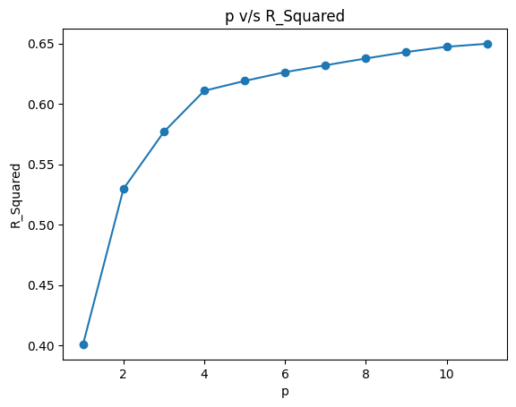

```python
plt.scatter(p_R_Squared['p'], p_R_Squared['R_Squared'])
plt.plot(p_R_Squared['p'], p_R_Squared['R_Squared'])

plt.xlabel('p')
plt.ylabel('R_Squared')
plt.title('p v/s R_Squared')

plt.show()
```

Model having all the columns has the best R-Squared.

```
2. Using Adjusted R-Squared
```

```python
p_Adjusted_R_Squared = (eval_metrics.groupby('p')["Adjusted R_Squared"].max()).reset_index()

index = eval_metrics.loc[eval_metrics['Adjusted R_Squared'] == eval_metrics['Adjusted R_Squared'].max()].index[0]

d = (eval_metrics.iloc[index, :]).reset_index()
d = d.T
d.columns = d.iloc[0]
d = d.drop('index')
d["Crietria"] = "Adjusted R-Squared"
d

best_models = pd.concat([best_models, d], ignore_index=True)
```

```python
best_Adjusted_rsquared_index = eval_metrics.groupby('p')['Adjusted R_Squared'].idxmax()
best_Adjusted_rsquared = eval_metrics.loc[best_Adjusted_rsquared_index, ["p", "Variables in Model", "Adjusted R_Squared"]]

best_Adjusted_rsquared.to_csv(r"C:\Users\hp\Downloads\Semester 2 Project\best_Adjusted_rsquared.csv", sep=',', index=False, header=True)

best_Adjusted_rsquared
```

|  | p | Variables in Model | Adjusted R_Squared |
| --- | --- | --- | --- |
| 2 | 1 | [x3] | 0.395476 |
| 12 | 2 | [x1, x3] | 0.521028 |
| 77 | 3 | [x1, x3, x9] | 0.565149 |
| 283 | 4 | [x1, x3, x9, x7_4] | 0.596429 |
| 690 | 5 | [x1, x3, x9, x7_4, x6_2] | 0.601191 |
| 1173 | 6 | [x1, x3, x4, x9, x7_4, x6_2] | 0.605129 |
| 1541 | 7 | [x1, x2, x3, x9, x10, x7_2, x7_4] | 0.607432 |
| 1836 | 8 | [x1, x2, x3, x4, x9, x10, x7_2, x7_4] | 0.609717 |
| 1981 | 9 | [x1, x2, x3, x4, x5, x9, x10, x7_2, x7_4] | 0.611724 |
| 2035 | 10 | [x1, x2, x3, x4, x5, x9, x10, x7_2, x7_3, x7_4] | 0.612704 |
| 2046 | 11 | [x1, x2, x3, x4, x5, x9, x10, x7_2, x7_3, x7_4... | 0.611631 |

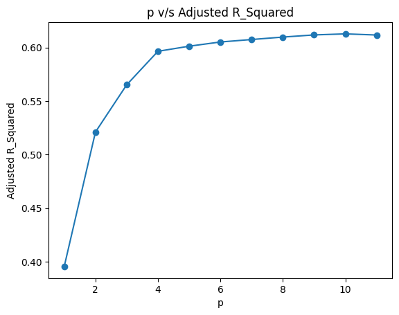

```python
plt.scatter(p_Adjusted_R_Squared['p'], p_Adjusted_R_Squared['Adjusted R_Squared'])
plt.plot(p_Adjusted_R_Squared['p'], p_Adjusted_R_Squared['Adjusted R_Squared'])

plt.xlabel('p')
plt.ylabel('Adjusted R_Squared')
plt.title('p v/s Adjusted R_Squared')

plt.show()
```

```
3. Using SSE
```

```python
p_SSE = (eval_metrics.groupby('p')["SSE"].min()).reset_index()

index = eval_metrics.loc[eval_metrics['SSE'] == eval_metrics['SSE'].min()].index[0]

d = (eval_metrics.iloc[index, :]).reset_index()
d = d.T
d.columns = d.iloc[0]
d = d.drop('index')
d["Crietria"] = "SSE"
d

best_models = pd.concat([best_models, d], ignore_index=True)
```

```python
best_sse_index = eval_metrics.groupby('p')['SSE'].idxmin()
best_sse = eval_metrics.loc[best_sse_index, ["p", "Variables in Model", "SSE"]]

best_sse.to_csv(r"C:\Users\hp\Downloads\Semester 2 Project\best_sse.csv", sep=',', index=False, header=True)

best_sse
```

|  | p | Variables in Model | SSE |
| --- | --- | --- | --- |
| 2 | 1 | [x3] | 120.652009 |
| 12 | 2 | [x1, x3] | 94.732827 |
| 77 | 3 | [x1, x3, x9] | 85.224596 |
| 283 | 4 | [x1, x3, x9, x7_4] | 78.368449 |
| 690 | 5 | [x1, x3, x9, x7_4, x6_2] | 76.726724 |
| 1173 | 6 | [x1, x3, x4, x9, x7_4, x6_2] | 75.259096 |
| 1541 | 7 | [x1, x2, x3, x9, x10, x7_2, x7_4] | 74.114347 |
| 1836 | 8 | [x1, x2, x3, x4, x9, x10, x7_2, x7_4] | 72.981182 |
| 1981 | 9 | [x1, x2, x3, x4, x5, x9, x10, x7_2, x7_4] | 71.907776 |
| 2035 | 10 | [x1, x2, x3, x4, x5, x9, x10, x7_2, x7_3, x7_4] | 71.029884 |
| 2046 | 11 | [x1, x2, x3, x4, x5, x9, x10, x7_2, x7_3, x7_4... | 70.528391 |

Model having all the columns has the best SSE.

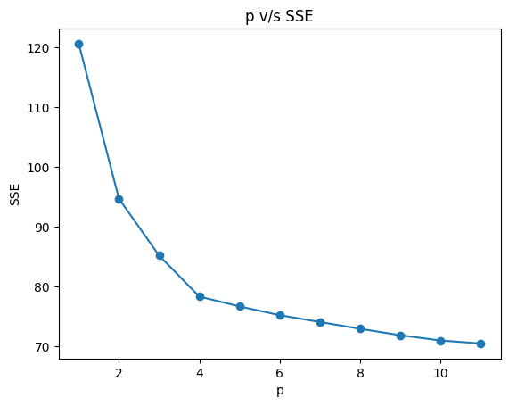

```python
plt.plot(p_SSE['p'], p_SSE['SSE'])
plt.scatter(p_SSE['p'], p_SSE['SSE'])

plt.xlabel('p')
plt.ylabel('SSE')
plt.title('p v/s SSE')

plt.show()
```

```
4. Using Mallow's Statistic (Cp)
```

```python
p_Cp = eval_metrics[["p", "Cp", "Variables in Model"]]
```

```python
p_Cp["p-Cp"] = abs(p_Cp["p"] - p_Cp["Cp"])
```

```python
index = p_Cp.loc[p_Cp['p-Cp'] == p_Cp['p-Cp'].min()].index[0]

d = (eval_metrics.iloc[index, :]).reset_index()
d = d.T
d.columns = d.iloc[0]
d = d.drop('index')
d["Crietria"] = "Cp"
d

best_models = pd.concat([best_models, d], ignore_index=True)
```

```python
best_cp = p_Cp.groupby('p')['p-Cp'].idxmin()
best_cp = p_Cp.loc[best_cp, ["p", "Variables in Model", "Cp"]]

best_cp.to_csv(r"C:\Users\hp\Downloads\Semester 2 Project\best_cp.csv", sep=',', index=False, header=True)

best_cp
```

|  | p | Variables in Model | Cp |
| --- | --- | --- | --- |
| 2 | 1 | [x3] | 35.492981 |
| 12 | 2 | [x1, x3] | 6.452140 |
| 78 | 3 | [x1, x3, x10] | 5.037413 |
| 352 | 4 | [x2, x3, x4, x9] | 3.385785 |
| 781 | 5 | [x2, x3, x4, x9, x6_2] | 5.113109 |
| 1196 | 6 | [x1, x3, x5, x10, x7_2, x6_2] | 5.838969 |
| 1701 | 7 | [x2, x3, x4, x5, x9, x7_2, x6_2] | 7.160137 |
| 1954 | 8 | [x2, x3, x4, x9, x7_2, x7_3, x7_4, x6_2] | 8.137746 |
| 2026 | 9 | [x2, x3, x4, x5, x9, x10, x7_2, x7_3, x6_2] | 8.133507 |
| 2045 | 10 | [x2, x3, x4, x5, x9, x10, x7_2, x7_3, x7_4, x6_2] | 7.991127 |
| 2046 | 11 | [x1, x2, x3, x4, x5, x9, x10, x7_2, x7_3, x7_4... | -4.535119 |

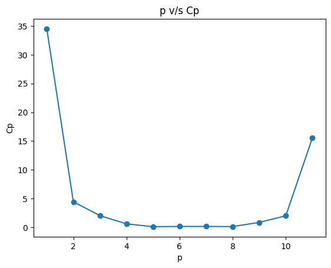

```python
p_Cp_ = (p_Cp.groupby('p')["p-Cp"].min()).reset_index()
plt.scatter(p_Cp_['p'], p_Cp_['p-Cp'])
plt.plot(p_Cp_['p'], p_Cp_['p-Cp'])

plt.xlabel('p')
plt.ylabel('Cp')
plt.title('p v/s Cp')

plt.show()
```

```
5. AIC
```

```python
p_AIC = (eval_metrics.groupby('p')["AIC"].min()).reset_index()

index = eval_metrics.loc[eval_metrics['AIC'] == eval_metrics['AIC'].min()].index[0]

d = (eval_metrics.iloc[index, :]).reset_index()
d = d.T
d.columns = d.iloc[0]
d = d.drop('index')
d["Crietria"] = "AIC"
d

best_models = pd.concat([best_models, d], ignore_index=True)
```

```python
best_AIC = eval_metrics.groupby('p')['AIC'].idxmin()
best_AIC = eval_metrics.loc[best_AIC, ["p", "Variables in Model", "AIC"]]

best_AIC.to_csv(r"C:\Users\hp\Downloads\Semester 2 Project\best_AIC.csv", sep=',', index=False, header=True)

best_AIC
```

|  | p | Variables in Model | AIC |
| --- | --- | --- | --- |
| 2 | 1 | [x3] | 11.404056 |
| 12 | 2 | [x1, x3] | -13.924978 |
| 77 | 3 | [x1, x3, x9] | -23.877044 |
| 283 | 4 | [x1, x3, x9, x7_4] | -31.354205 |
| 690 | 5 | [x1, x3, x9, x7_4, x6_2] | -31.746565 |
| 1173 | 6 | [x1, x3, x4, x9, x7_4, x6_2] | -31.928969 |
| 1541 | 7 | [x1, x2, x3, x9, x10, x7_2, x7_4] | -31.660991 |
| 1836 | 8 | [x1, x2, x3, x4, x9, x10, x7_2, x7_4] | -31.402039 |
| 1981 | 9 | [x1, x2, x3, x4, x5, x9, x10, x7_2, x7_4] | -31.076385 |
| 2035 | 10 | [x1, x2, x3, x4, x5, x9, x10, x7_2, x7_3, x7_4] | -30.464445 |
| 2046 | 11 | [x1, x2, x3, x4, x5, x9, x10, x7_2, x7_3, x7_4... | -29.265090 |

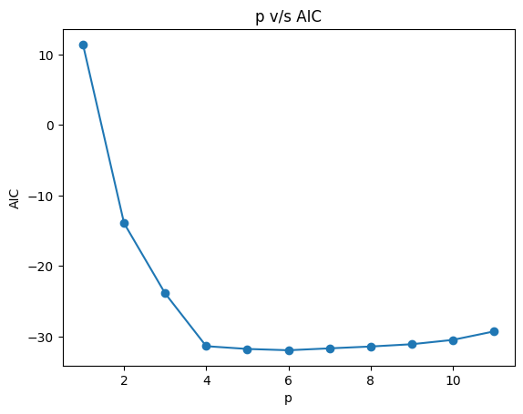

```python
plt.scatter(p_AIC['p'], p_AIC['AIC'])
plt.plot(p_AIC['p'], p_AIC['AIC'])

plt.xlabel('p')
plt.ylabel('AIC')
plt.title('p v/s AIC')

plt.show()
```

```
6. BIC
```

```python
p_BIC = (eval_metrics.groupby('p')["BIC"].min()).reset_index()

index = eval_metrics.loc[eval_metrics['BIC'] == eval_metrics['BIC'].min()].index[0]

d = (eval_metrics.iloc[index, :]).reset_index()
d = d.T
d.columns = d.iloc[0]
d = d.drop('index')
d["Crietria"] = "BIC"
d

best_models = pd.concat([best_models, d], ignore_index=True)
```

```python
best_BIC = eval_metrics.groupby('p')['BIC'].idxmin()
best_BIC = eval_metrics.loc[best_BIC, ["p", "Variables in Model", "BIC"]]

best_BIC.to_csv(r"C:\Users\hp\Downloads\Semester 2 Project\best_BIC.csv", sep=',', index=False, header=True)

best_BIC
```

|  | p | Variables in Model | BIC |
| --- | --- | --- | --- |
| 2 | 1 | [x3] | 16.858832 |
| 12 | 2 | [x1, x3] | -5.742814 |
| 77 | 3 | [x1, x3, x9] | -12.967493 |
| 283 | 4 | [x1, x3, x9, x7_4] | -17.717266 |
| 690 | 5 | [x1, x3, x9, x7_4, x6_2] | -15.382238 |
| 1173 | 6 | [x1, x3, x4, x9, x7_4, x6_2] | -12.837254 |
| 1541 | 7 | [x1, x2, x3, x9, x10, x7_2, x7_4] | -9.841889 |
| 1836 | 8 | [x1, x2, x3, x4, x9, x10, x7_2, x7_4] | -6.855549 |
| 1981 | 9 | [x1, x2, x3, x4, x5, x9, x10, x7_2, x7_4] | -3.802507 |
| 2035 | 10 | [x1, x2, x3, x4, x5, x9, x10, x7_2, x7_3, x7_4] | -0.463179 |
| 2046 | 11 | [x1, x2, x3, x4, x5, x9, x10, x7_2, x7_3, x7_4... | 3.463564 |

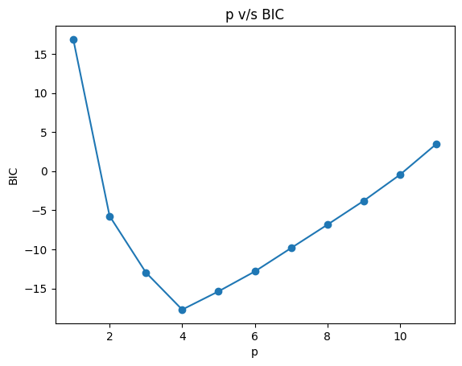

```python
plt.scatter(p_BIC['p'], p_BIC['BIC'])
plt.plot(p_BIC['p'], p_BIC['BIC'])

plt.xlabel('p')
plt.ylabel('BIC')
plt.title('p v/s BIC')

plt.show()
```

```
7. Using Backward Elimination Technique
```

```python
model = sm.OLS(y, x).fit()
# Perform backward elimination

while True:
    # Extract p-values for each feature
    p_values = model.pvalues

    # Find the feature with the highest p-value
    feature_to_remove = p_values.idxmax()

    # Check if the highest p-value exceeds a significance level (e.g., 0.05)
    if p_values[feature_to_remove] > 0.05:
        # Step 4e: Remove the feature from X and refit the model
        x = x.drop(feature_to_remove, axis=1)
        model = sm.OLS(y, x).fit()
    else:
        break  # Exit the loop when no feature has a p-value above the significance level

# Step 5: Final model with selected features
final_model = model
```

```python
final_model.summary()
```

OLS Regression Results

| Dep. Variable: | y | R-squared (uncentered): | 0.962 |
| --- | --- | --- | --- |
| Model: | OLS | Adj. R-squared (uncentered): | 0.960 |
| Method: | Least Squares | F-statistic: | 687.5 |
| Date: | Sat, 27 Apr 2024 | Prob (F-statistic): | 2.53e-76 |
| Time: | 11:39:08 | Log-Likelihood: | -147.09 |
| No. Observations: | 113 | AIC: | 302.2 |
| Df Residuals: | 109 | BIC: | 313.1 |
| Df Model: | 4 |  |  |
| Covariance Type: | nonrobust |  |  |

|  | coef | std err | t | P>\|t\| | [0.025 | 0.975] |
| --- | --- | --- | --- | --- | --- | --- |
| x1 | 0.6912 | 0.107 | 6.430 | 0.000 | 0.478 | 0.904 |
| x3 | 0.9152 | 0.130 | 7.017 | 0.000 | 0.657 | 1.174 |
| x5 | -587.4862 | 134.675 | -4.362 | 0.000 | -854.408 | -320.564 |
| x7_4 | 0.4984 | 0.244 | 2.043 | 0.044 | 0.015 | 0.982 |

| Omnibus: | 1.628 | Durbin-Watson: | 1.975 |
| --- | --- | --- | --- |
| Prob(Omnibus): | 0.443 | Jarque-Bera (JB): | 1.478 |
| Skew: | 0.279 | Prob(JB): | 0.477 |
| Kurtosis: | 2.952 | Cond. No. | 6.62e+03 |

Notes:  
[1] R² is computed without centering (uncentered) since the model does not contain a constant.  
[2] Standard Errors assume that the covariance matrix of the errors is correctly specified.  
[3] The condition number is large, 6.62e+03. This might indicate that there are  
strong multicollinearity or other numerical problems.

Therefore, by backward elimination technique, the best model selected is having four variables **[x1, x3, x5, x7_4]**

```python
bm = LinearModel(df2[["x1", "x3", "x5", "x7_4", "y"]])
```

```python
d = pd.DataFrame()
d.loc[0, "Variables in Model"] = 3
d.loc[0, "p"] = int(4)
d.loc[0, "SSE"] = bm.SSE
d.loc[0, "R_Squared"] = bm.r_squared()
d.loc[0, "Adjusted R_Squared"] = bm.adjustedr_squared()
d.loc[0, "Cp"] = bm.Cp(MSE)
d.loc[0, "AIC"] = bm.AIC()
d.loc[0, "BIC"] = bm.BIC()
d.loc[0, "Crietria"] = "Backward Elimination"

best_models = pd.concat([best_models, d], ignore_index=True)
```

```python
best_models.at[6, "Variables in Model"] = ['x1', 'x3', "x5", "x7_4"]
```

```python
best_models
```

|  | Variables in Model | p | SSE | R_Squared | Adjusted R_Squared | Cp | AIC | BIC | Crietria |
| --- | --- | --- | --- | --- | --- | --- | --- | --- | --- |
| 0 | [x1, x2, x3, x4, x5, x9, x10, x7_2, x7_3, x7_4... | 11 | 70.528391 | 0.649774 | 0.611631 | -4.535119 | -29.26509 | 3.463564 | R-Squared |
| 1 | [x1, x2, x3, x4, x5, x9, x10, x7_2, x7_3, x7_4] | 10 | 71.029884 | 0.647284 | 0.612704 | -5.934531 | -30.464445 | -0.463179 | Adjusted R-Squared |
| 2 | [x1, x2, x3, x4, x5, x9, x10, x7_2, x7_3, x7_4... | 11 | 70.528391 | 0.649774 | 0.611631 | -4.535119 | -29.26509 | 3.463564 | SSE |
| 3 | [x2, x3, x4, x9, x6_2] | 5 | 88.604717 | 0.560012 | 0.539452 | 5.113109 | -15.481908 | 0.882419 | Cp |
| 4 | [x1, x3, x4, x9, x7_4, x6_2] | 6 | 75.259096 | 0.626283 | 0.605129 | -8.869622 | -31.928969 | -12.837254 | AIC |
| 5 | [x1, x3, x9, x7_4] | 4 | 78.368449 | 0.610843 | 0.596429 | -9.145858 | -31.354205 | -17.717266 | BIC |
| 6 | [x1, x3, x5, x7_4] | 4.0 | 79.986114 | 0.60281 | 0.588099 | -7.20854 | -29.04543 | -15.408491 | Backward Elimination |

```python
best_models.columns
```

```
Index(['Variables in Model', 'p', 'SSE', 'R_Squared', 'Adjusted R_Squared',
       'Cp', 'AIC', 'BIC', 'Crietria'],
      dtype='object')
```

```python
best_models = best_models[['Crietria', 'Variables in Model', 'p', 'SSE', 'R_Squared', 'Adjusted R_Squared',
       'Cp', 'AIC', 'BIC']]
```

```python
best_models
```

|  | Crietria | Variables in Model | p | SSE | R_Squared | Adjusted R_Squared | Cp | AIC | BIC |
| --- | --- | --- | --- | --- | --- | --- | --- | --- | --- |
| 0 | R-Squared | [x1, x2, x3, x4, x5, x9, x10, x7_2, x7_3, x7_4... | 11 | 70.528391 | 0.649774 | 0.611631 | -4.535119 | -29.26509 | 3.463564 |
| 1 | Adjusted R-Squared | [x1, x2, x3, x4, x5, x9, x10, x7_2, x7_3, x7_4] | 10 | 71.029884 | 0.647284 | 0.612704 | -5.934531 | -30.464445 | -0.463179 |
| 2 | SSE | [x1, x2, x3, x4, x5, x9, x10, x7_2, x7_3, x7_4... | 11 | 70.528391 | 0.649774 | 0.611631 | -4.535119 | -29.26509 | 3.463564 |
| 3 | Cp | [x2, x3, x4, x9, x6_2] | 5 | 88.604717 | 0.560012 | 0.539452 | 5.113109 | -15.481908 | 0.882419 |
| 4 | AIC | [x1, x3, x4, x9, x7_4, x6_2] | 6 | 75.259096 | 0.626283 | 0.605129 | -8.869622 | -31.928969 | -12.837254 |
| 5 | BIC | [x1, x3, x9, x7_4] | 4 | 78.368449 | 0.610843 | 0.596429 | -9.145858 | -31.354205 | -17.717266 |
| 6 | Backward Elimination | [x1, x3, x5, x7_4] | 4.0 | 79.986114 | 0.60281 | 0.588099 | -7.20854 | -29.04543 | -15.408491 |

```python
best_models.to_csv(r"C:\Users\hp\Downloads\Semester 2 Project\best_models.csv", sep=',', index=False,header=True)
```

[output not shown]

[output cut: 69 more lines]

Residual analysis

- Normality
- brown forsyth for heterosedasticity check

Influential observation analysis

- DFBETAS
- DEFFITS
- Cook's

```
def adjustedr_squared(self):
    # Get Adjusted R-Squared
    return (1 - (self.SSE/self.dfSSE)/(self.SSTO/self.dfSSTO))

def Cp(self, MSE):
    # Get Cp
    return ((self.SSE/MSE) - self.n + 2 * self.p)

def AIC(self):
    # Get AIC
    return (self.n * np.log(self.SSE/self.n) + 2 * self.p)

def BIC(self):
    # Get BIC
    return (self.n * np.log(self.SSE/self.n) + np.log(self.n) * self.p)
```

```python
criteria = list(best_models["Crietria"])
```

```python
count = 0
for i in best_models['Variables in Model']:
    x = list(i)
    var = x + ['y']
    model = LinearModel(df2[var])

    plt.scatter(model.y_pred, model.residual)
    plt.xlabel("Predicted y")
    plt.ylabel('Residual')
    plt.title(f'Residual Plot : {x} on criteria {criteria[count]}')

    plt.show()
    probplot(model.residual, dist="norm", plot = plt)
    plt.xlabel("Theoretical Quantile")
    plt.ylabel('Calculated Quantile')
    plt.title(f'QQ Plot : {x} on criteria {criteria[count]}')
    plt.show()
    count += 1
```

[output not shown]

```python
# Split the array into two arrays of 50 elements each
from scipy.stats import t
def brown_forsyth(res_trans):
    n = 113
    res_1 = np.array(res_trans)[0:56]
    res_2 = np.array(res_trans)[56 : n]
    e1_tilda = np.median(res_1)
    e2_tilda = np.median(res_2)

    abs_dev_1 = np.abs(res_1 - e1_tilda)
    abs_dev_2 = np.abs(res_2 - e2_tilda)

    d1_bar = np.mean(abs_dev_1)
    d2_bar = np.mean(abs_dev_2)

    s2 = (np.sum((abs_dev_1 - d1_bar)**2) + np.sum((abs_dev_2 - d2_bar)**2))/(n-2)
    ts = (d1_bar - d2_bar)/((s2*(1/56 + (1/(57))))**0.5)
    print(ts)
    alpha=0.05
    df=n-2

    t_tab = t.ppf(1 - alpha/2, df)
    if(abs(ts)>t_tab):
      print("There is heteroscedasticity")
    else:
      print("There is homoscedasticity.")
```

```python
j = 0
for i in best_models['Variables in Model']:
    x = list(i)
    var = x + ['y']
    model = LinearModel(df2[var])
    residual = model.residual
    print(f'For criteria {criteria[j]} is')
    brown_forsyth(residual)
    j+=1
```

```
For criteria R-Squared is
0.33601541576093824
There is homoscedasticity.
For criteria Adjusted R-Squared is
0.43969246005557383
There is homoscedasticity.
For criteria SSE is
0.33601541576093824
There is homoscedasticity.
For criteria Cp is
-0.042056148210292944
There is homoscedasticity.
For criteria AIC is
-0.07956377736939477
There is homoscedasticity.
For criteria BIC is
-0.22851508902952322
There is homoscedasticity.
For criteria Backward Elimination is
-0.6514016979157893
There is homoscedasticity.
```

## Influential Observation Analysis

```python
from statsmodels.stats.outliers_influence import OLSInfluence
```

```python
def cooks_distance(X):
    # Assuming you have your independent variables in X and dependent variable in y
    n = 113
    # Fit the regression model
    y = df2['y']
    X = df2[X]
    X = sm.add_constant(X)  # Add a constant term if needed
    model = sm.OLS(y, X).fit()

    # Get the OLSInfluence object
    influence = OLSInfluence(model)

    # Calculate Cook's distance
    cooks_d = influence.cooks_distance
    dffits = influence.dffits

    threshold_cooks = 4/n
    # Print Cook's distance for influencial observation

    influencial_cooks = []

    influencial_dffits = []

    print("Index for influential observation using cooks distance:")

    for i, cook_d in enumerate(list(cooks_d[0])):
        if(cook_d > threshold_cooks):
            print(f"Observation index {i}")
            influencial_cooks.append((i,cook_d))

    print("Index for influential observation using dffits:")

    for j, fits in enumerate(list(dffits[0])):
        if(fits > dffits[1]):
            print(f"Observation index {j}")
            influencial_dffits.append((j, fits))

    # return value tuple of two tuples : 1st for cooks distance ( 1st list of cooks distance , list of tuples of influencial index and distance)
    #                                  : 2nd for dffits ( ist list of dffit value , list of tuples of influencial index and dffit value )
    return (((list(cooks_d[0]),influencial_cooks), (list(dffits[0]) , influencial_dffits)))
```

```python
cooks_distances = {}
count = 0
for i in best_models['Variables in Model']:
   print(f"influential observations in {criteria[count]}")
   cooks_distances[f'{criteria[count]}']= cooks_distance(i)[0]
   count += 1
```

```python
dffits_dict = {}
count = 0
for j in best_models['Variables in Model']:
   print(f"influential observations in {criteria[count]}")
   dffits_dict[f'{criteria[count]}']= cooks_distance(j)[1]
   count += 1
```

```
influential observations in R-Squared
Index for influential observation using cooks distance:
Observation index 9
Observation index 36
Observation index 37
Observation index 52
Observation index 53
Observation index 58
Observation index 62
Observation index 99
Observation index 100
Observation index 102
Observation index 111
Index for influential observation using dffits:
Observation index 9
Observation index 37
Observation index 52
Observation index 53
Observation index 62
Observation index 99
influential observations in Adjusted R-Squared
Index for influential observation using cooks distance:
Observation index 9
Observation index 36
Observation index 37
Observation index 52
Observation index 53
Observation index 62
Observation index 95
Observation index 100
Observation index 102
Observation index 111
Index for influential observation using dffits:
Observation index 9
Observation index 37
Observation index 52
Observation index 53
Observation index 62
influential observations in SSE
Index for influential observation using cooks distance:
```

[output cut: 72 more lines]

```
Observation index 24
Observation index 37
Observation index 46
Observation index 56
Observation index 62
Observation index 95
Observation index 100
Observation index 102
Observation index 111
Observation index 112
Index for influential observation using dffits:
Observation index 37
Observation index 56
Observation index 62
Observation index 112
```

```python
dffits_dict
```

[output not shown]

[output cut: 774 more lines]

[output not shown]

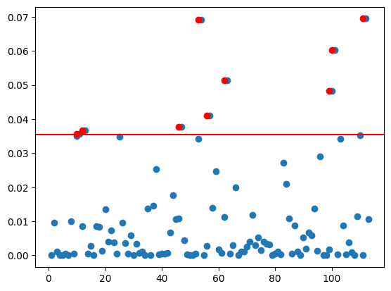

```python
# creating list of index and cooks distance of influential observations
f = []
s = []
for i, j in cooks_distances['AIC'][1]:
    f.append(i)
    s.append(j)
# plot of the cooks distance
plt.axhline(4/113 , color = "r")
plt.scatter(np.arange(start = 1 , stop = 114)  ,cooks_distances['AIC'][0])
plt.scatter(f,s , color = "r" )
```

```python
cooks_distances['AIC']
```

```python
# Assuming you have your independent variables in X and dependent variable in y
X = df2[['x1', 'x3', 'x9', 'x7_4']]
y = df2['y']
# Fit the regression model
X = sm.add_constant(X)  # Add a constant term if needed
model = sm.OLS(y, X).fit()

# Get the OLSInfluence object
influence = OLSInfluence(model)

# Calculate DFFITS
dffits = influence.dffits  # DFFITS for all observations
# or you can use influence.dffits[0, :] for individual observations

# Calculate DFBETAS
dfbetas = influence.dfbetas  # DFBETAS for all observations

# Print DFFITS and DFBETAS for each observation
# for i, (dfb, dffit) in enumerate(zip(dfbetas, dffits)):
#     print(f"Observation {i}: DFFITS = {dffit}, DFBETAS = {dfb}")

dffits[1]
list(dffits[0])
```

[output not shown]

[output cut: 58 more lines]

[output not shown]